# PSTAT 131 Final Project

2024-06-15

# Table of Contents

1. Introduction
2. Data Adjustments and Variable Selection
3. Exploratory Data Analysis
4. Data Splitting and Cross-Validation
5. Recipe
6. Model Creation
7. Model Autoplots
8. Model Results
9. Fitting Best Model to Training Set
10. Testing Results and Variable Importance
11. Conclusion

```r
library(tidymodels)
library(tidyverse)
library(glmnet)
library(ggthemes)
library(janitor)
library(ranger)
library(vip)
```

```r
library(corrplot)
library(forcats)
tidymodels_prefer()
Pop_df <- read.csv(file = "~/Downloads/rain_df.csv")
```

## Introduction

The purpose of this project is to accurately predict the quantity of olive oil that will be extracted in Palestine. This prediction is based on several factors including environmental variables such as temperature and rainfall, as well as economic factors like input costs and the number of employees hired. Understanding these relationships helps in better forecasting and planning for olive oil production, which is a significant agricultural product in the region.

To gather the necessary data for this project, we utilized resources from the [Palestine Central Bureau of Statistics](https://www.pcbs.gov.ps/default.aspx). This involved collecting comprehensive data for each region in Palestine, resulting in a large and detailed dataset. This dataset includes variables such as Governate, Year, Annual Rainfall, Max Temperature, Employees, Costs, Inflation-adjusted Costs, Previous Year Oil Production, and the Quantity of Oil Extracted. By analyzing this data, we aim to identify key predictors. We will be splitting the data into training-testing sets and will be building multiple models, then reviewing the models to see which one is the best for predicting Olive Oil output.

## Data Adjustments and Variable Selection

First we can start by turning any categorical variables into factors. In our data frame is our data which consists of 136 observations. Each observation includes the Governate, Year, Annual_rainfall, Max_temp, Employees, Costs, Inflation_adj, Previous_Year_Oil, as well as our predictor Quantity_Oil_Extracted. Since our Inflation_adj variable is Costs adjusted for Inflation we can hence ignore Cost. We will also not include Year and focus on the other predictors of interest.

```r
nrow(Pop_df)
```

```
## [1] 136
```

```r
Pop_df <- Pop_df %>%
  mutate(
    Governate = factor(Governate)
  )
```

## Exploratory Data Analysis

Missing Data

There were few missing data points in the Annual_rainfall and Max_temp column. This was handled by using the values of Annual_rainfall and Max_temp from other regions that were not missing data, to predict the missing values. Since this was addressed before hand, ensuring a complete data set before importation, the code is provided below.

```r
Temps <- data.frame(
  Year = c(2019, 2018, 2017, 2016, 2015, 2014, 2013, 2012, 2011, 2010, 2009,2008,2007, 2005, 2004, 2003, 2001, 2000, 1999, 1998, 1997),
  Gaza_temps = c(NA,NA,NA,NA,NA,NA,NA,NA,NA,NA,NA,NA, 23.6, 23.6, 23.6, 23.5, 24.0, 23.4, 24.1, 24.7, 22.1),
  Hebron_temps = pal_rain_df[pal_rain_df$Governate == "Hebron" & pal_rain_df$Year %in% c(2019, 2018, 2017, 2016, 2015, 2014, 2013, 2012, 2011, 2010, 2009,2008, 2007, 2005, 2004, 2003, 2001, 2000, 1999, 1998, 1997),]$Max_temp,
  Jenin_temps =pal_rain_df[pal_rain_df$Governate == "Jenin" & pal_rain_df$Year %in% c(2019, 2018, 2017, 2016, 2015, 2014, 2013, 2012, 2011, 2010, 2009,2008, 2007, 2005, 2004, 2003, 2001, 2000, 1999, 1998, 1997),]$Max_temp,
  Nablus_temps = pal_rain_df[pal_rain_df$Governate == "Nablus" & pal_rain_df$Year %in% c(2019, 2018, 2017, 2016, 2015, 2014, 2013, 2012, 2011, 2010, 2009,2008, 2007, 2005, 2004, 2003, 2001, 2000, 1999, 1998, 1997),]$Max_temp,
  Ramallah_temps = pal_rain_df[pal_rain_df$Governate == "Ramallah" & pal_rain_df$Year %in% c(2019, 2018, 2017, 2016, 2015, 2014, 2013, 2012, 2011, 2010, 2009,2008, 2007, 2005, 2004, 2003, 2001, 2000, 1999, 1998, 1997),]$Max_temp,
  Tulkarm_temps =pal_rain_df[pal_rain_df$Governate == "Tulkarm" & pal_rain_df$Year %in% c(2019, 2018, 2017, 2016, 2015, 2014, 2013, 2012, 2011, 2010, 2009, 2008, 2007, 2005, 2004, 2003, 2001, 2000, 1999, 1998, 1997),]$Max_temp,
  Bethlehem_temps = c(NA,22.3, 22.7, 23.2, 22.4, 22.3, 23.6, 23.6,NA,NA,NA,NA,NA,NA,NA,NA,NA,NA,NA,NA, NA)

)
Temps

Rain <- data.frame(
  Year = c(2019, 2018, 2017, 2016, 2015, 2014, 2013, 2012, 2011, 2010, 2009,2008,2007, 2005, 2004, 2003, 2001, 2000, 1999, 1998, 1997),
  Gaza_rain = c(NA,NA,NA,NA,NA,NA,NA,NA,NA,NA,NA,NA, 405.1, 260.5, 408.3, 524.8, 436.7, 563.3, 196.5, 241.1, 353.8),
  Hebron_rain = pal_rain_df[pal_rain_df$Governate == "Hebron" & pal_rain_df$Year %in% c(2019, 2018, 2017, 2016, 2015, 2014, 2013, 2012, 2011, 2010, 2009,2008, 2007, 2005, 2004, 2003, 2001, 2000, 1999, 1998, 1997),]$Annual_rainfall,
  Jenin_rain =pal_rain_df[pal_rain_df$Governate == "Jenin" & pal_rain_df$Year %in% c(2019, 2018, 2017, 2016, 2015, 2014, 2013, 2012, 2011, 2010, 2009,2008, 2007, 2005, 2004, 2003, 2001, 2000, 1999, 1998, 1997),]$Annual_rainfall,
  Nablus_rain = pal_rain_df[pal_rain_df$Governate == "Nablus" & pal_rain_df$Year %in% c(2019, 2018, 2017, 2016, 2015, 2014, 2013, 2012, 2011, 2010, 2009,2008, 2007, 2005, 2004, 2003, 2001, 2000, 1999, 1998, 1997),]$Annual_rainfall,
  Ramallah_rain = pal_rain_df[pal_rain_df$Governate == "Ramallah" & pal_rain_df$Year %in% c(2019, 2018, 2017, 2016, 2015, 2014, 2013, 2012, 2011, 2010, 2009,2008, 2007, 2005, 2004, 2003, 2001, 2000, 1999, 1998, 1997),]$Annual_rainfall,
  Tulkarm_rain =pal_rain_df[pal_rain_df$Governate == "Tulkarm" & pal_rain_df$Year %in% c(2019, 2018, 2017, 2016, 2015, 2014, 2013, 2012, 2011, 2010, 2009, 2008, 2007, 2005, 2004, 2003, 2001, 2000, 1999, 1998, 1997),]$Annual_rainfall

)
Rain
Tulkarm_temp_mod <- lm(Tulkarm_temps~ Hebron_temps+ Jenin_temps+Nablus_temps+Ramallah_temps, data = filter_all(Temps[,-2], all_vars(!is.na(.) & . != 0)))

Ramallah_temp_mod <- lm(Ramallah_temps~ Hebron_temps+ Jenin_temps+Nablus_temps, data = filter_all(Temps[,-2], all_vars(!is.na(.) & . != 0)))

Bethlehem_temp_mod <- lm(Bethlehem_temps~ Hebron_temps+ Jenin_temps+Nablus_temps, data = filter_all(Temps[2:8,-2], all_vars(!is.na(.) & . != 0)))

Gaza_rain_mod <- lm(Gaza_rain~ Hebron_rain+ Jenin_rain+Nablus_rain+Tulkarm_rain, data = filter_all(Rain[,], all_vars(!is.na(.) & . != 0)))

Ramallah_rain_mod <- lm(Ramallah_rain~ Hebron_rain+ Jenin_rain+Nablus_rain+Tulkarm_rain, data = filter_all(Rain[,], all_vars(!is.na(.) & . != 0)))

#pal_rain_df[pal_rain_df$Governate == "Ramallah" & is.na(pal_rain_df$Annual_rainfall), ]$Annual_rainfall <- predict(Ramallah_rain_mod, newdata =Rain %>%filter(is.na(Ramallah_rain)) )

#pal_rain_df[pal_rain_df$Governate == "Gaza" & is.na(pal_rain_df$Annual_rainfall), ]$Annual_rainfall <- predict(Gaza_rain_mod, newdata =Rain %>%filter(is.na(Gaza_rain)) )

#pal_rain_df[pal_rain_df$Governate == "Ramallah" & is.na(pal_rain_df$Max_temp), ]$Max_temp <- predict(Ramallah_temp_mod, newdata =Temps %>%
  #filter(is.na(Ramallah_temps)) )

#pal_rain_df[pal_rain_df$Governate == "Bethlehem" & is.na(pal_rain_df$Max_temp), ]$Max_temp <- predict(Bethlehem_temp_mod, newdata =Temps %>%filter(is.na(Bethlehem_temps)) )[2:4]

#pal_rain_df[pal_rain_df$Governate == "Tulkarm" & is.na(pal_rain_df$Max_temp), ]$Max_temp <- predict(Tulkarm_temp_mod, newdata =Temps %>%
  #filter(is.na(Tulkarm_temps)) )
#pal_rain_df[pal_rain_df$Governate == "Gaza" & is.na(pal_rain_df$Max_temp), ]$Max_temp <- predict(lm(Gaza_temps~ Hebron_temps+ Jenin_temps+Nablus_temps+Tulkarm_temps, data = Temps[,-6]), newdata = Temps[1:12,])
```

First lets plot the distribution of our outcome, Quantity_Oil_Extracted. Second we can see the correlation between variables with a correlation plot. Next we can use a boxplot to see the distribution of Olive Oil output by Governate.

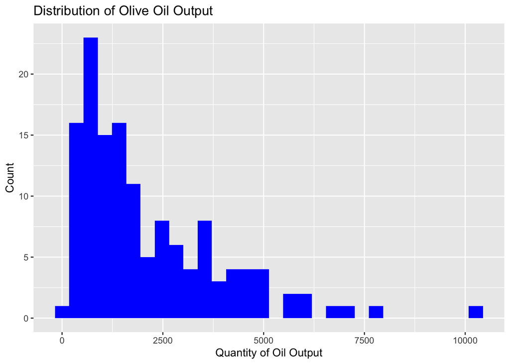

```r
ggplot(Pop_df, aes(Quantity_Oil_Extracted)) +
  geom_histogram( fill = "blue") +
  labs(
    title = "Distribution of Olive Oil Output",
    x = "Quantity of Oil Output",
    y = "Count"
  )
```

```r
min(Pop_df$Quantity_Oil_Extracted)
```

```
## [1] 176.8
```

```r
max(Pop_df$Quantity_Oil_Extracted)
```

```
## [1] 10442.32
```

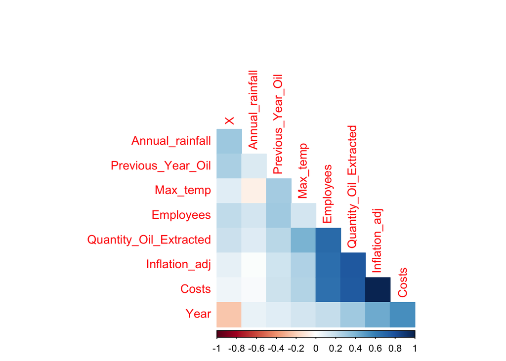

```r
corrplot(corr_matrix <- cor(Pop_df[, sapply(Pop_df, is.numeric)]), type = 'lower', diag = FALSE,
           method = 'color', order = "AOE")
```

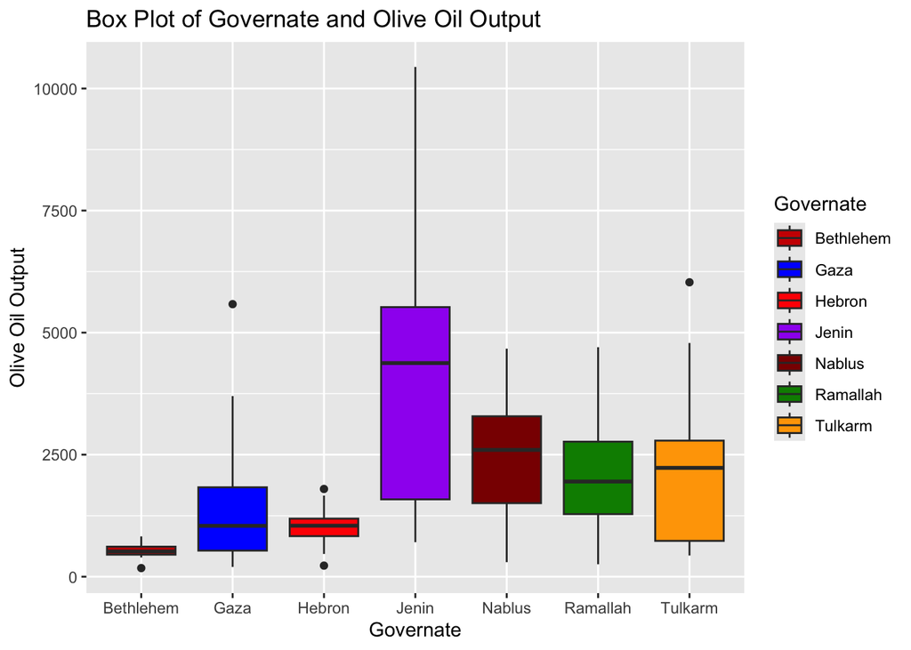

```r
Pop_df %>%
  ggplot(aes(x = Governate, y = Quantity_Oil_Extracted, fill = Governate)) +
  geom_boxplot() +
  labs(
    title = "Box Plot of Governate and Olive Oil Output",
    y = "Olive Oil Output",
    x = "Governate") +
  scale_fill_manual(values = c("red3", "blue1", "red1", "purple", "red4", "green4", "orange"))
```

## Results

In our Histogram we can see that our outcome variable has a strong rightward skew and has few observations with really high values. The range is 176.8 to 10442.32. Many of these really high values are from the Year 2019 which saw a large spike in Olive Oil Extraction.

The correlation plot shows a strong positive correlation with employees and Costs/Inflation_adj which is to be expected. The strongest correlation with respect to our outcome variable came from Employees and from Costs/Inflation_adj. Meaning that as Employees and Costs/Inflation_adj increase our outcome variables increases alongside it. There seemed to be much less correlation from the environmental factors like Max_temp and Annual_rainfall and our outcome variable. Meaning that as Max_temp and Annual_rainfall increase, Quantity_Oil_Extracted increases slightly.

In our Boxplot there is significant differences in Olive Oil Output based on Governate. Jenin has the largest spread and the most Olive Oil production with Bethlehem having the least. It should also be noted that there are few observations for Bethlehem.

## Data Splitting and Cross-Validation

We will split the data into training and testing sets using a 70/30 split. The split ensures that our model learns patterns from the majority of the data in the training set and is then tested on a separate portion to determine its predictive power.

We also stratified our splits based on the outcome variable, which ensures that the distribution is similar in both training and test sets. This helps in maintaining equal representation in the data.

Instead of relying on a single train-test split, we divide the training set into multiple subsets and validate the model multiple times. This helps in understanding the model’s testing accuracy by using the average of multiple tests rather than just one. We used k-fold cross-validation with 5 folds. This means that the training data is split into 5 parts. This process entails using 4 parts for training and the last for validation and the process is repeated 5 times. The folds were also stratified based on Quantity_Oil_Extracted to ensure an equal distribution

## Recipe

To create a recipe in order to use in all of our models we will utilize the following predictors: Governate, Annual_rainfall, Max_temp, Employees, Inflation_adj, and Previous_Year_Oil.We can start by dummy-coding our categorical variable, Governate using step_dummy. We can then normalize the variables by centering and scaling using step_center and step_scale.

```r
set.seed(100)
pop_split <- initial_split(Pop_df, prop = 0.7, strata = Quantity_Oil_Extracted)
pop_train <- training(pop_split)
pop_test <- testing(pop_split)
k_folds <- vfold_cv(pop_train, v = 5, strata = Quantity_Oil_Extracted)
k_folds
```

```
## #  5-fold cross-validation using stratification
## # A tibble: 5 × 2
##   splits          id
##   <list>          <chr>
## 1 <split [72/20]> Fold1
## 2 <split [72/20]> Fold2
## 3 <split [72/20]> Fold3
## 4 <split [76/16]> Fold4
## 5 <split [76/16]> Fold5
```

```r
pop_recipe <- recipe(Quantity_Oil_Extracted~Governate +Annual_rainfall+ Max_temp+ Employees+ Inflation_adj + Previous_Year_Oil, data = pop_train) %>%
  step_dummy(all_nominal_predictors()) %>%
  step_center(all_predictors()) %>%
  step_scale(all_predictors())
(pop_recipe)
```

```
## ── Recipe ──────────────────────────────────────────────────────────────────────
```

```
## ── Inputs
```

```
## Number of variables by role
```

```
## outcome:   1
## predictor: 6
```

```
## ── Operations
```

```
## • Dummy variables from: all_nominal_predictors()
```

```
## • Centering for: all_predictors()
```

```
## • Scaling for: all_predictors()
```

```r
bake(prep(pop_recipe), new_data = pop_test)
```

```
## # A tibble: 44 × 12
##    Annual_rainfall Max_temp Employees Inflation_adj Previous_Year_Oil
##              <dbl>    <dbl>     <dbl>         <dbl>             <dbl>
##  1         -1.63    -0.339     -1.53         -1.05             -0.944
##  2          0.233    0.0543    -1.47         -0.726            -0.938
##  3         -0.329    0.574      5.61          2.17              0.156
##  4         -0.572    0.689      2.20          0.458             0.820
##  5          0.915    0.685      2.59          1.43             -0.404
##  6          0.804    0.436     -0.563        -0.141            -0.381
##  7         -0.809    0.330      0.432         0.870            -0.896
##  8          0.0912   0.0107    -1.18         -0.993            -0.235
##  9          0.326   -0.0330    -0.839        -1.08             -0.985
## 10         -1.91     0.273     -1.32         -1.28             -1.17
## # ℹ 34 more rows
## # ℹ 7 more variables: Quantity_Oil_Extracted <dbl>, Governate_Gaza <dbl>,
## #   Governate_Hebron <dbl>, Governate_Jenin <dbl>, Governate_Nablus <dbl>,
## #   Governate_Ramallah <dbl>, Governate_Tulkarm <dbl>
```

## Model Creation

Now that we have prepared our data, it’s time to build and evaluate our models. We will be using a variety of models to predict the Quantity_Oil_Extracted. As a metric for determining model predictability we can use RMSE. RMSE is the Root Mean Squared Error which measures how far the estimates are from the real values. A very large RMSE means that your predictions tend to be far away from the real Quantity_Oil_Extracted while a lower RMSE means they are quite close. We of course would like to achieve a low RMSE and will choose the best model based on this metric.

Our models will include a basic Linear model, Elastic Net regression, Random Forest and K-Nearest Neighbors. For all of our models we will set the mode to regression rather than classification.

For our KNN model we will tune the neighbors using neighbors_grid which will allow us to choose from 1-10 neighbors. For the Random Forest model the parameters we will be tuning are the number of Trees, min_n(how large each node is), and mtry which is the number of predictors to consider at each split. We can us rf_grid for this. For the Elastic Net regression model we will tune mixture and penalty using elastic_grid.

```r
pop_lm <- linear_reg() %>%
  set_engine("lm") %>%
  set_mode("regression")

pop_wkflow_lm <- workflow() %>%
  add_model(pop_lm) %>%
  add_recipe(pop_recipe)



pop_knn <- nearest_neighbor(neighbors = tune()) %>%
  set_engine("kknn") %>%
  set_mode("regression")

pop_wkflow_knn <- workflow() %>%
  add_model(pop_knn) %>%
  add_recipe(pop_recipe)



pop_rf_spec <- rand_forest(mtry = tune(),
                           trees = tune(),
                           min_n = tune()) %>%
  set_engine("ranger", importance = "impurity") %>%
  set_mode("regression")

pop_rf_wkflow <- workflow() %>%
  add_model(pop_rf_spec) %>%
  add_recipe(pop_recipe)

pop_elast_model <- linear_reg(penalty = tune(), mixture = tune()) %>%
  set_engine("glmnet") %>%
  set_mode("regression")

pop_elast_workflow <- workflow() %>%
  add_model(pop_elast_model) %>%
  add_recipe(pop_recipe)
```

```r
rf_grid <- grid_regular(mtry(range = c(1, 6)),
                        trees(range = c(200, 700)),
                        min_n(range = c(10, 20)),
                        levels = 6)
rf_grid
```

```
## # A tibble: 216 × 3
##     mtry trees min_n
##    <int> <int> <int>
##  1     1   200    10
##  2     2   200    10
##  3     3   200    10
##  4     4   200    10
##  5     5   200    10
##  6     6   200    10
##  7     1   300    10
##  8     2   300    10
##  9     3   300    10
## 10     4   300    10
## # ℹ 206 more rows
```

```r
neighbors_grid <- grid_regular(neighbors(range = c(1, 10)), levels = 10)
neighbors_grid
```

```
## # A tibble: 10 × 1
##    neighbors
##        <int>
##  1         1
##  2         2
##  3         3
##  4         4
##  5         5
##  6         6
##  7         7
##  8         8
##  9         9
## 10        10
```

```r
elast_grid <- grid_regular(penalty(range = c(1, 5),
                                     trans = identity_trans()), mixture(), levels = 10)
elast_grid
```

```
## # A tibble: 100 × 2
##    penalty mixture
##      <dbl>   <dbl>
##  1    1          0
##  2    1.44       0
##  3    1.89       0
##  4    2.33       0
##  5    2.78       0
##  6    3.22       0
##  7    3.67       0
##  8    4.11       0
##  9    4.56       0
## 10    5          0
## # ℹ 90 more rows
```

```r
knn_tune <- tune_grid(
  object = pop_wkflow_knn,
  resamples = k_folds,
  grid = neighbors_grid
)

elast_tune <- tune_grid(
  object = pop_elast_workflow,
  resamples = k_folds,
  grid = elast_grid
)

rf_tune <- tune_grid(

  object = pop_rf_wkflow,
  resamples = k_folds,
  grid = rf_grid)

lm_fit_val <- pop_wkflow_lm %>%
  fit_resamples(resamples = k_folds)
```

## Model Autoplots

We can use autoplot to measure the effects of our tuned parameters on the resulting RMSE with 3 of our models.

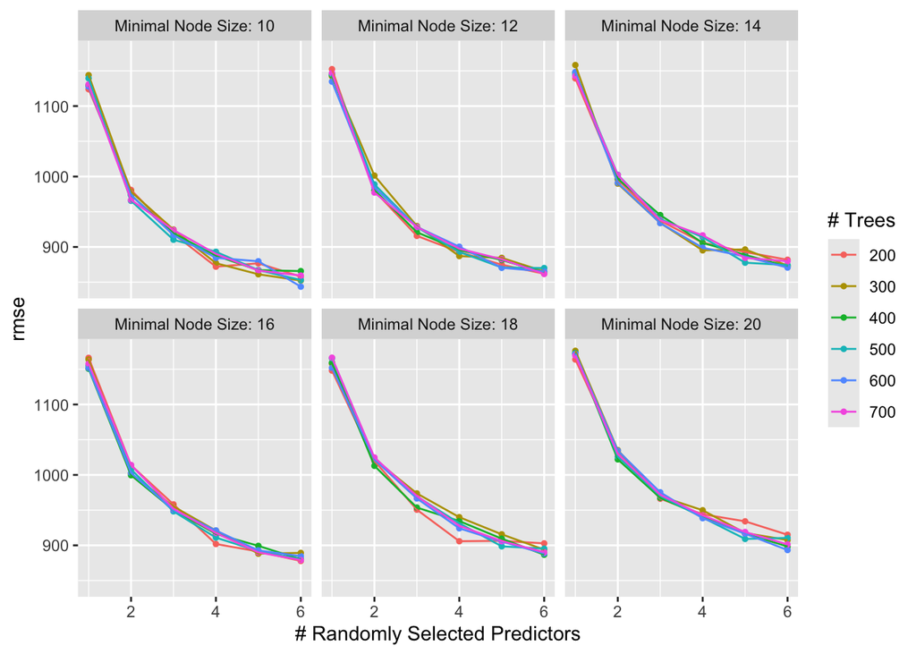

```r
autoplot(rf_tune, metric = "rmse")
```

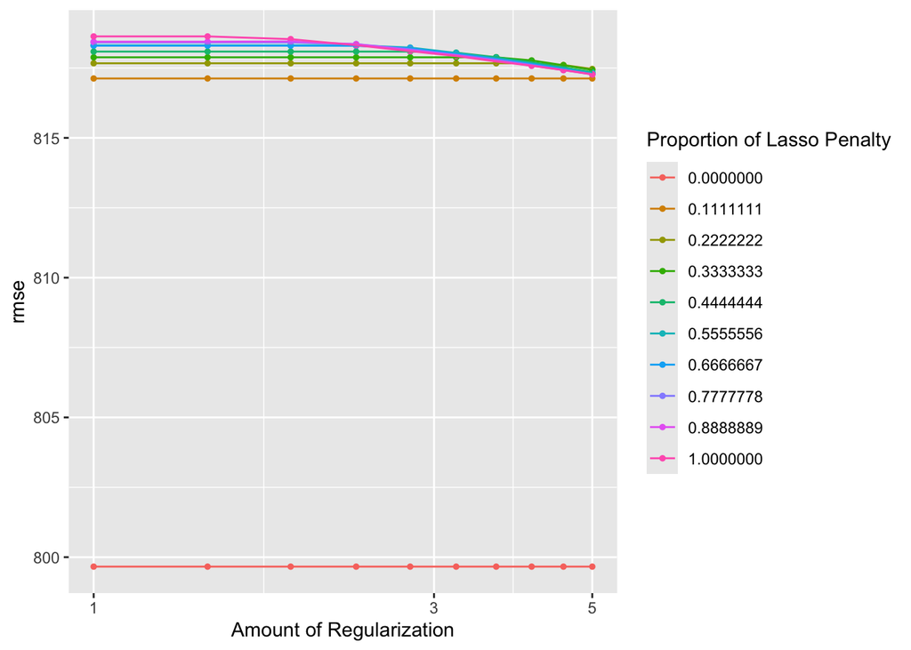

```r
autoplot(elast_tune, metric = "rmse")
```

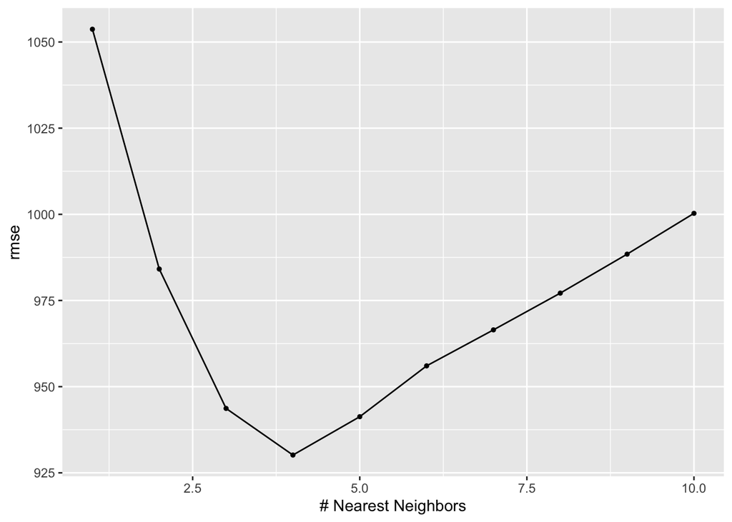

```r
autoplot(knn_tune, metric = "rmse")
```

```r
 lm_lowest_rmse <- collect_metrics(lm_fit_val)[1,]$mean
 knn_lowest_rmse <-(collect_metrics(knn_tune) %>%
  filter(.metric == "rmse") %>%
  arrange(mean)  )[1,]$mean

 rf_lowest_rmse <- (collect_metrics(rf_tune) %>%
  filter(.metric == "rmse") %>%
  arrange(mean))[1,]$mean


 elast_lowest_rmse <-(collect_metrics(elast_tune) %>%
  filter(.metric == "rmse") %>%
  arrange(mean) )[1,]$mean
```

[figure not shown]

```r
Best_RMSE_df <- data.frame(
  Model = c("Linear", "Elastic Net Regression", "Random Forest", "KNN"),
  RMSE = c(lm_lowest_rmse, elast_lowest_rmse, knn_lowest_rmse, rf_lowest_rmse)
)

ggplot(Best_RMSE_df, aes(x = Model, y = RMSE, fill = Model)) +
  geom_bar(stat = "identity", color = "black", width = 0.7) +
  geom_text(aes(label = round(RMSE, 2)), vjust = -0.5, size = 5) +
  labs(
    title = "RMSE for Different Models",
    x = "Model",
    y = "Root Mean Squared Error (RMSE)"
  ) +
  theme_minimal()
```

## Fitting Best Model to Training Set

We will use our Elastic Net Regression model that performed best on our k-folds by fitting it to the training set. Then we will test how it performs on the test data.

```r
elast_best <- select_best(elast_tune, metric = 'rmse')
elast_best
```

```
## # A tibble: 1 × 3
##   penalty mixture .config
##     <dbl>   <dbl> <chr>
## 1       1       0 Preprocessor1_Model001
```

```r
final_elast_worflow <- finalize_workflow(pop_elast_workflow, elast_best)
final_pop_train <- fit(final_elast_worflow , data = pop_train)
```

```r
final_data_test <- augment(final_pop_train, pop_test)
test_rmse <- final_data_test %>%
  metrics(truth = Quantity_Oil_Extracted, estimate = .pred)
test_rmse
```

```
## # A tibble: 3 × 3
##   .metric .estimator .estimate
##   <chr>   <chr>          <dbl>
## 1 rmse    standard    1080.
## 2 rsq     standard       0.749
## 3 mae     standard     733.
```

## Testing Results and Variable Importance

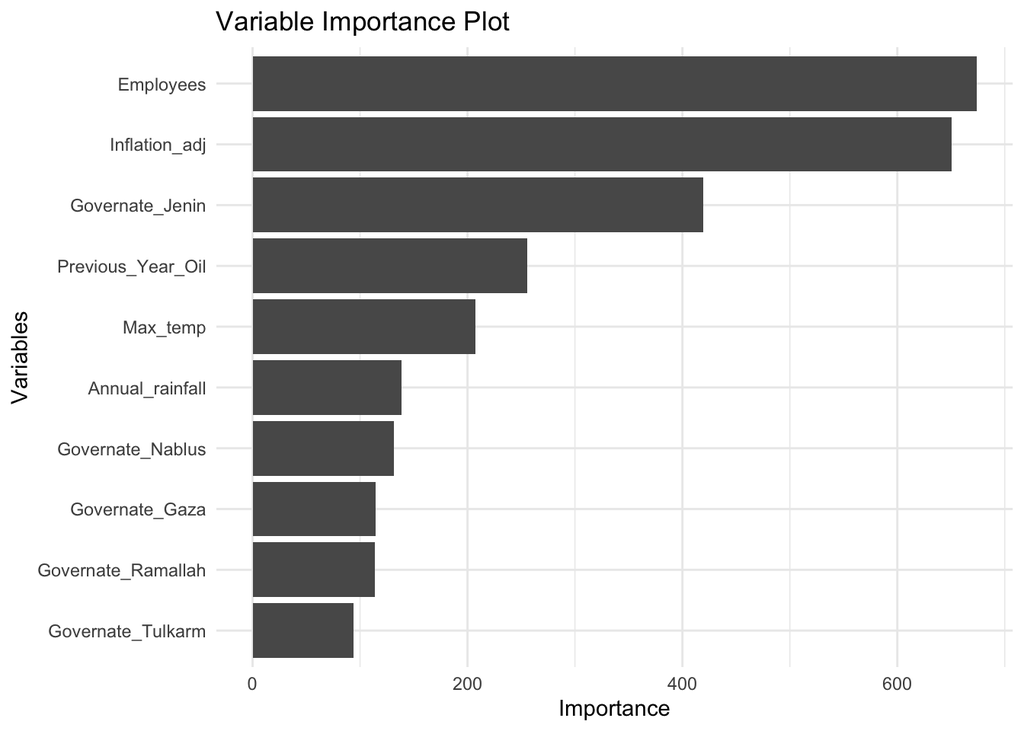

```r
final_pop_train %>%
  extract_fit_parsnip() %>%
  vip() +
  theme_minimal() +
  labs(
    title = "Variable Importance Plot",
    x = "Variables",
    y = "Importance"
  )
```

## Conclusion

In this analysis, we aimed to predict the quantity of Olive Oil production in Palestine using various predictive models. We utilized a range of predictors, including environmental variables, economic factors, and previous oil production data. Our dataset was carefully preprocessed, with categorical variables converted to factors, and predictors normalized.

We explored the data through visualization techniques, identifying key patterns and correlations. The exploratory data analysis revealed that the number of employees and costs adjusted for inflation were the most significant factors influencing olive oil output, while environmental factors had a lesser impact.

The analysis highlighted the importance of economic factors in predicting olive oil production and demonstrated the utility of different regression techniques. Despite the higher RMSE on the test set, the R-squared value of 0.7485 indicates a good proportion of variability explained by the model.

Future work could involve exploring additional features, model tuning, and incorporating more sophisticated techniques to improve accuracy. Overall, this project provided me with valuable insights into the key drivers of Olive Oil production in Palestine and most importantly the application of various regression models.